# Text Mining Project - M2 Data Mining

FOSSIER Camille - NEBBACHE Nabih

20/12/2019

# Visualisation du corpus

Ce document a pour objectif de visualiser un peu mieux les données du corpus en utilisant les données du corpus enrichi et la modélisation des thématiques.

# Axes de visualisation

## Observation des thématiques

Regardons ce que contiennent les thématiques obtenues :

```r
source("functions.R")
topics = read.csv(topics_path)
corpus = read.csv(corpus_path,sep="\t", stringsAsFactors=F)

relevant_docs = relevant_topic_documents(topics, corpus$titles, 30)
relevant_docs
```

```
##       V1
##  [1,] "Sri Lanka Army Starts a Drive Against Tamil Rebels in North"
##  [2,] "Salvador Amnesty Offer"
##  [3,] "Quotation of the Day"
##  [4,] "A 4-Hour Barracks Takeover Ends Peaceably in Argentina"
##  [5,] "Sri Lanka Emergency Stays"
##  [6,] "No Headline"
##  [7,] "Bhutto Tries to Regain Her Office"
##  [8,] "Israeli Opposition Elects New Leader"
##  [9,] "South African Whites Demand Their Own Bantustan"
## [10,] "Japanese Leaders Await Voters' Verdict"
## [11,] "Four Years After His Death, Marcos Is Buried"
## [12,] "Rockefeller, Javits, Lindsay . . . Millard?"
## [13,] "De Klerk and Tutu Talk On Ending Black Strife"
## [14,] "Egypt Seizes 60 Militants"
```

[output cut: 109 more lines]

Les 4 topics enregistrés dans le csv sont donnés à titre d’exemple, mais il serait possible de refaire une extraction de thématiques et de réutiliser les outils que nous allons voir par la suite pour mener d’autres analyses.

Essayons de nommer les 4 thématiques ci-dessus :

- Les deux premières semblent contenir beaucoup de noms de pays différents. La première semble toucher à des affaires militaires. Nous appellerons donc cette catégorie : Conflits internationaux. La seconde semble plus particulièrement toucher à de la politique, donc nous l’appellerons : Politique internationale.
- La troisième thématique semble toucher à des affaires judiciaires, en effet il est question de “Corrections”, de “Fraude”, d’“éthique”, et des mots comme “case” (affaire), “attorney” (avocat), “trial” (procès), confirment cette idée : Justice.
- Enfin la quatrième concerne de manière évidente des affaires soviétiques : URSS.

Choisissons une granularité trimestrielle pour observer les articles. Nous allons donc regarder l’évolution de la probabilité d’observer une thématique dans le corpus à chaque trimestre.

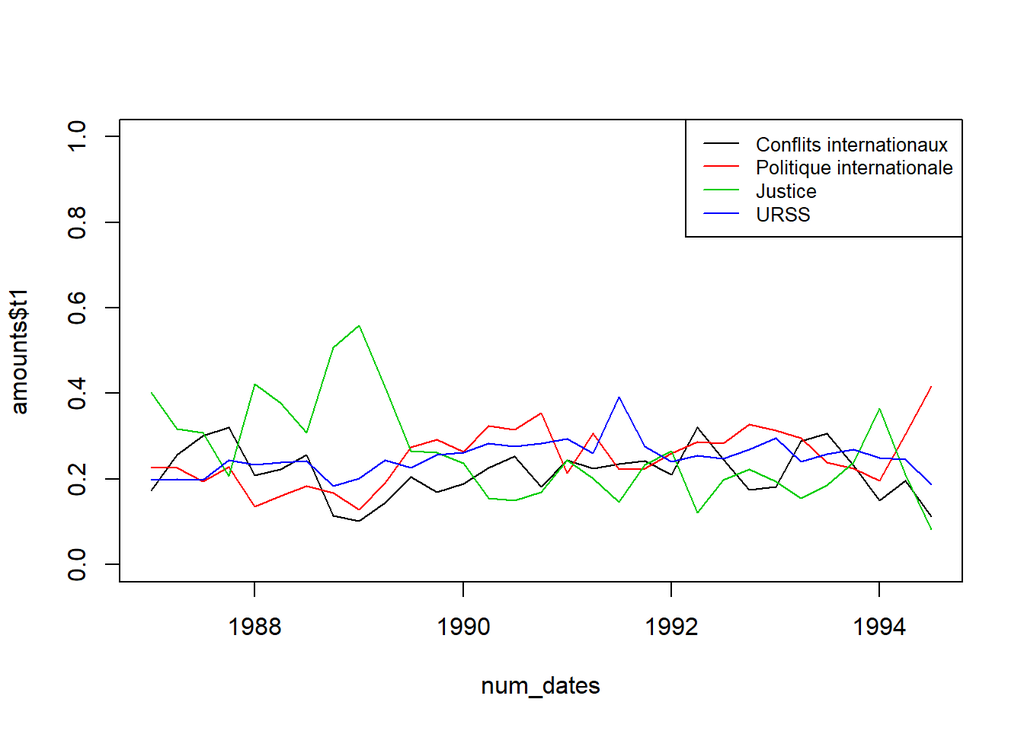

```r
dates = as.POSIXlt(corpus$dates)
dates = to_trimestrial_dates(dates)

topics_d = topics
topics_d$dates <- unlist(lapply(dates, format))


amounts = group_by_dates(topics_d,
               t1 = mean(V1),
               t2 = mean(V2),
               t3 = mean(V3),
               t4 = mean(V4))

num_dates = as.POSIXlt(amounts$dates)

plot(num_dates, amounts$t1, col=1, ylim=c(0,1), type="l")
lines(num_dates, amounts$t2, col=2, ylim=c(0,1))
lines(num_dates, amounts$t3, col=3, ylim=c(0,1))
lines(num_dates, amounts$t4, col=4, ylim=c(0,1))

legend("topright",
       col=(1:4),
       lty=1,
       cex=0.8,
       legend=c("Conflits internationaux",
                "Politique internationale",
                "Justice",
                "URSS"))
```

Entre 1987 et 1990 on observe une forte variation de l’importance du sujet 3 : Justice.

Commençons par regarder l’évolution de cette thématique avec une granularité plus fine, par exemple par mois.

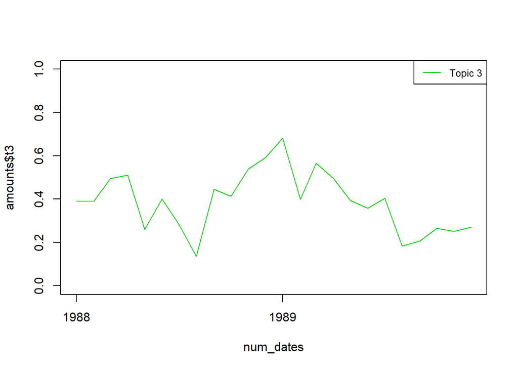

```r
# filter_dates returns indices of dates that are between the specified range
filtered_dates = filter_dates(corpus$dates, date_min="1988-01-01", date_max="1990-01-01")
filtered_topics = topics[filtered_dates, 3]

dates = corpus$dates[filtered_dates]
dates = to_monthly_dates(as.POSIXlt(dates))

topics_d = data.frame("V3"=filtered_topics)
topics_d$dates <- unlist(lapply(dates, format))

amounts = group_by_dates(topics_d,
               t3 = mean(V3))

num_dates = as.POSIXlt(amounts$dates)

plot(num_dates, amounts$t3, col=3, ylim=c(0,1), type="l")

legend("topright",
       col=3,
       lty=1,
       cex=0.8,
       legend="Topic 3")
```

## Liens entre certaines entités

Essayons d’explorer les personnes et les lieux évoqués dans les articles de cette époque :

```r
# Reading extracted entities
entities = read.csv(entities_path)

# Only keeping the ones from the filtered dates
entities = entities[entities$doc_id %in% filtered_dates,]

# Generating matrices of apparition in documents for entities
entities_matrices = get_doc_matrices(entities)
```

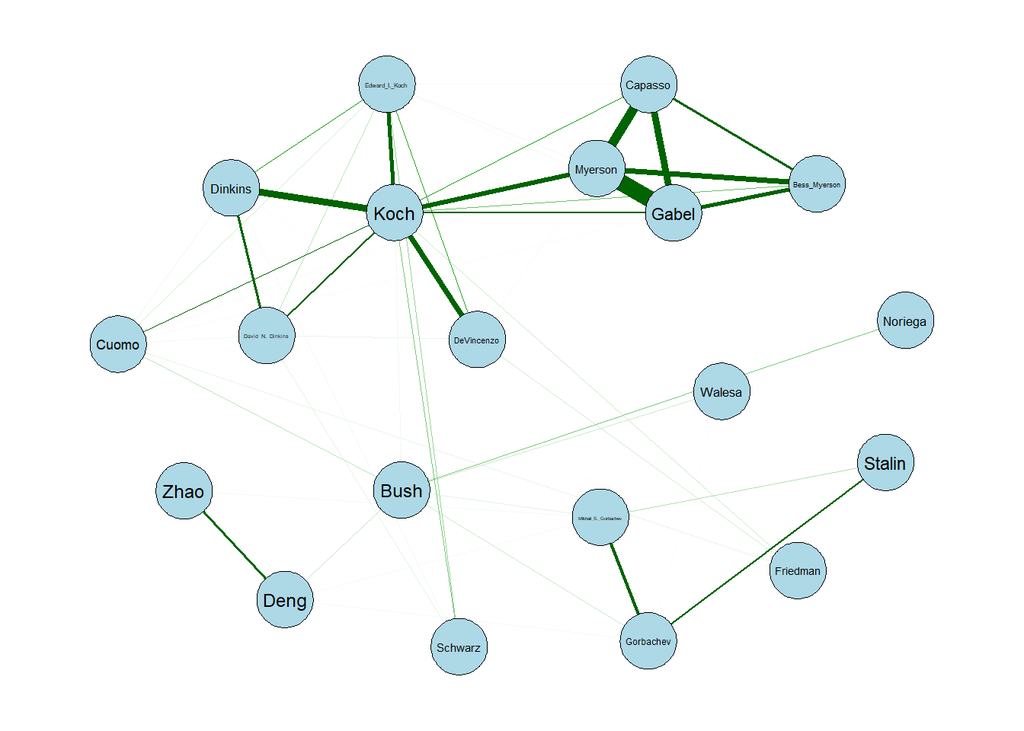

```r
persons = entities_matrices$PERSON

# Keeping persons that appear the most often
ord = order(rowSums(persons), decreasing = T)
small_pers = persons[ord[1:20],]

# Computing cooccurences of people with other people
cooc = small_pers %*% t(small_pers)

# Removing self cooccurences
for (i in 1:nrow(cooc)){
  cooc[i,i] = 0
}

# Plot
library(qgraph)
qgraph(cooc,
       layout="spring",
       vsize=6,
       labels=dimnames(persons)[[1]][ord[1:20]],
       arrows=F,
       color="lightblue")
```

On voit sur ce graphe un ensemble de personnes plus ou moins concernées par les mêmes sujets. Concentrons nous sur une poignée d’entre eux, et effectuons une recherche contenant leurs noms pour en apprendre plus sur eux.

```r
filtered_corpus = corpus[filtered_dates,]

iterator = get_iterator(filtered_corpus$texts)
vocabulary = get_vocabulary(iterator)
dtm = get_dtm(vocabulary, iterator)
dtm.tfidf = get_dtm_tfidf(dtm)

result = search(
  "koch dinkins myerson gabel capasso devincenzo",
  filtered_corpus$texts,
  vocabulary,
  dtm.tfidf,
  k=20
)
filtered_corpus$titles[result]
```

```
##  [1] "Myerson Jury Deliberates"
##  [2] "Aide to Koch Testifies About Hiring of Gabel"
##  [3] "Metro Datelines; Ex-Aide to Myerson Recalls a Warning"
##  [4] "The Envelope, Please"
##  [5] "Myerson Trial's Opening Statements to Start"
##  [6] "Shana Alexander Signed For a Book on Myerson"
##  [7] "Myerson and Judge Are Sued"
##  [8] "Corrections"
##  [9] "Witness Recalls Myerson's Anger at Newspaper Inquiry"
## [10] "The Three People on Trial"
## [11] "Human Rights Commissioner Recalls Hiring Sukhreet Gabel"
## [12] "Corrections"
## [13] "City Agency Found in Contempt in Myerson Case"
## [14] "Sukhreet Gabel Admits Her 'Deep Resentment'"
## [15] "Contempt Ruling Against Myerson Investigators Is Overturned"
## [16] "Another Judge Selected to Preside In Federal Case Against Myerson"
## [17] "Lawyer Terms Myerson Aliases Eccentric Ploy"
## [18] "Witness Tells Myerson Jury Of Capasso Guilty Tax Plea"
## [19] "Koch Aide Denies Lying in Myerson Trial"
## [20] "Judge's Daughter Is 'Smiling Through Tears'"
```

```r
filtered_corpus$texts[result[1]]
```

```
## [1] " LEAD: The jury in the Bess Myerson trial deliberated all day and adjourned at 9:30 P.M. yesterday without reaching a verdict. Ms. Myerson, a former New York City Cultural Affairs Commissioner, is charged with bribing a judge handling her companion's divorce case. The other defendants are he…
```

Essayons maintenant de regarder les liens entre les personnes et des lieux dans les articles de l’époque :

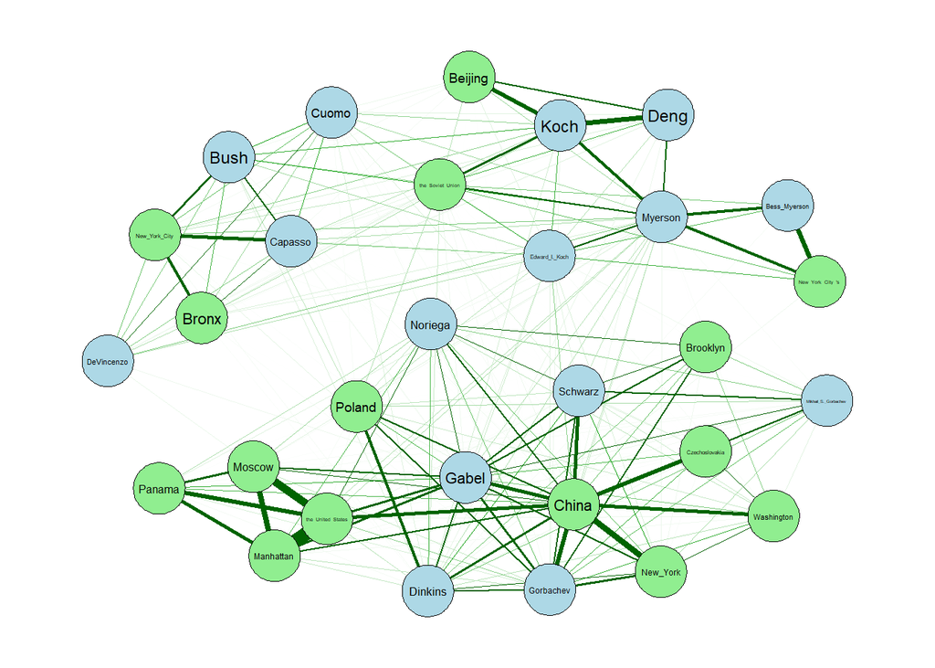

```r
place = entities_matrices$PLACE

# Keeping persons that appear the most often
ord_ev = order(rowSums(place), decreasing = T)
place_pers = rbind(place[ord_ev[1:15],], small_pers[1:15,])

# Computing cooccurences of people with other people
cooc = place_pers %*% t(place_pers)

# Removing self cooccurences
for (i in 1:nrow(cooc)){
  cooc[i,i] = 0
}

# Plot
library(qgraph)
qgraph(cooc,
       layout="spring",
       vsize=6,
       labels=c(dimnames(persons)[[1]][ord[1:15]], dimnames(place)[[1]][ord_ev[1:15]]),
       arrows=F,
       color=c(rep("lightblue",15), rep("lightgreen",15)))
```

# Supplémentaire

## Recherche par entité

On va rechercher dans le texte en spécifiant si ce que nous cherchons est : une personne, un lieu ou un événement. Le résultat de ces recherches nous renvoie tous les éléments de contexte autour de l’entité en question.

```r
ent_mat = load_entity_matrices()
search_entity("nixon", "PERSON",number_of_suggestions = 10, list_of_matrices = ent_mat)
```

```
## $NAME
## [1] "richard_nixon"
##
## $EVENT
## [1] "New_Year_'s_Eve"         "the_cold_war"
## [3] "Superfund"               "the_Cultural_Revolution"
## [5] "the_Super_Bowl"          "New_Year_'s"
## [7] "New_Year_'s_Day"
##
## $PERSON
##  [1] "Alfred_Del_Bello"   "Tran_Xuan_Bach"     "To_Huu"
##  [4] "Carter"             "O'Rourke"           "Reagan"
##  [7] "Alfonse_M._D'Amato" "Dao_Duy_Tung"       "Doan_Khue"
## [10] "Dong_Si_Nguyen"
##
## $PLACE
##  [1] "China"                          "the_United_States_Constitution"
##  [3] "us"                             "Brooklyn_Borough"
##  [5] "Beijing"                        "Manhattan"
##  [7] "Vietnam"                        "New_York_City"
##  [9] "Cambodia"                       "the_Empire_State"
##
## $ARTICLES
## [1] 4191   95 1377 2733 2784 2794 2824 6320
```

On peut aussi spécifier une plage de dates. Le resultat change puisque il contextualisé par le temps.

```r
dates = corpus$dates
search_entity("nixon", "PERSON", number_of_suggestions = 10, list_of_matrices = ent_mat,list_of_dates = dates, date_min = "1991-01-01", date_max = "1999-01-01"  )
```

```
## $NAME
## [1] "richard_nixon"
##
## $EVENT
## [1] "New_Year_'s_Eve" "New_Year_'s_Day"
##
## $PERSON
##  [1] "Sol_Wachtler"          "Lift"
##  [3] "Lady"                  "Edward_V._Regan"
##  [5] "Franklin_D._Roosevelt" "Lundine"
##  [7] "O'Rourke"              "Mario_Matthew_Cuomo"
##  [9] "Stan_Lundine"          "Abrams"
##
## $PLACE
## [1] "Albany"         "America"        "North_Carolina" "New_York_'s"
## [5] "New_York_State" "California"     "Florida"        "Iowa"
## [9] "Louisiana"
```

La même chose peut être faite pour les événements

```r
search_entity("bolshevik", "EVENT",number_of_suggestions = 10, list_of_matrices = ent_mat)
```

```
## $NAME
## [1] "the_bolshevik_revolution"
##
## $EVENT
## [1] "Superfund"       "New_Year_'s_Eve" "New_Year_'s_Day"
##
## $PERSON
##  [1] "Edward_N._Costikyan" "Mario_Matthew_Cuomo" "O'Rourke"
##  [4] "Reagan"              "Regan"               "Robert_Abrams"
##  [7] "William_Kennedy"     "Alfonse_M._D'Amato"  "Burgos"
## [10] "Freihofer"
##
## $PLACE
##  [1] "Bangkok"                        "Cambodia"
##  [3] "the_United_States"              "us"
##  [5] "New_Jersey"                     "Bicol"
##  [7] "Bronx"                          "Ohio"
##  [9] "Hanoi"                          "the_United_States_Constitution"
##
## $ARTICLES
## [1]  139 1306 1310 1797 3987 6317 6565
```